# Main Results for Memorability and Value-based Decisions

Xinyue Li

9/5/2021

## General Setup

```r
library(tidyverse)
library(dplyr)
library(lme4)
library(readr)
library(tidyr)
library(ggplot2)
library(sjPlot)
library(sjmisc)
library(Hmisc)
#library(plyr)
library(RColorBrewer)
library(reshape2)
library(glmmTMB)
library(corrplot)
require(gridExtra)

setwd("C:/Users/Christine/Box Sync/data/mem_dm_all_results/visualization")
```

## Experiment 1: Image Memorability (N = 199)

Load image memorability data from **cleaned_all_mem.csv** file.

(This file contains calculated memorability for images and words, as well as ResMem, HR, FAR. The original data can be found in **memorability_raw_full.csv** and **word_mem_full.csv** in the [raw data] folder respectively for image and word measurements.)

Participants who failed to have at least 3 correct hit and 3 correct reject were excluded.

```r
mem = read.csv("C:/Users/Christine/Box Sync/data/mem_dm_all_results/cleaned data/cleaned_all_mem.csv")
```

Load memorabilirty scores and data from file **stimchar_final_touse.csv** from Columbia Center for Eating Disorders (Lloyd et al., 2020).

Selected participants ages between 18-35, and calculated item-level average value for tasty and choice preference.

```r
food = read.csv("C:/Users/Christine/Box Sync/data/mem_dm_all_results/raw data/stimchar_final_touse.csv") %>% filter(age == "18-25" | age == "26-30" | age == "31-35")
```

### Distribution of memorability

Plot the distribution of image memorability scores. The vertical line represents for the median of memorability scores = 0.48

The lowest one is **saltine crackers**, and the highest one is **sliced pizza**

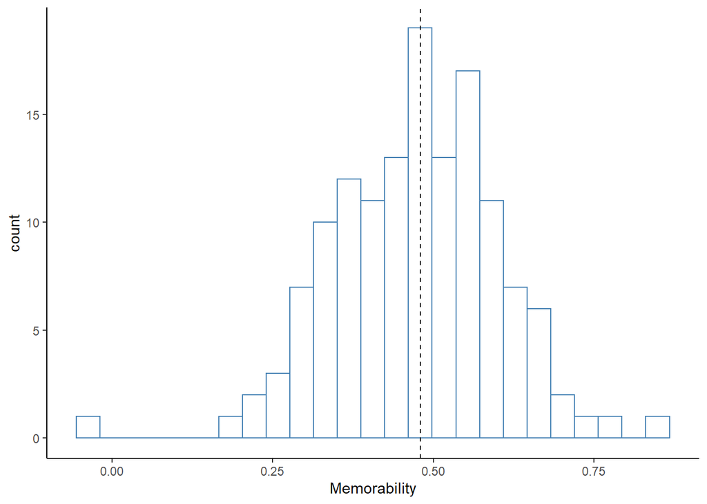

```r
## ggplot histogram
ggplot(mem, aes(x=Memorability)) +
  geom_histogram(color="steelblue", fill="white", bins = 25) +
  geom_vline(xintercept = 0.48,linetype = "dashed") +
  theme_classic()
```

```r
ggsave('C:/Users/Christine/Box Sync/data/mem_dm_all_results/visualization/hist_image.png', width = 7, height = 4, units = 'in')
```

### Correlation matrix

Plot for correlation matrix between 17 ratings and image memorbaility. **tasty, other tasty, feel, familiar** are positively related to image memorability.

```r
rdat = food %>% dplyr::select(stimulus, choice.rating, starts_with("rating"))
colnames(rdat) = sub("rating[.]", "", colnames(rdat))
colnames(rdat) = sub("[.]rating", "", colnames(rdat))

rmat = as.matrix(rdat[,-1])
rownames(rmat) = rdat$stimulus
rmat.nochoice = rmat[,-1]

new.ord = c("tasty", "othertasty", "feel", "texture", "disgusting", "familiar", "filling", "healthy", "sweetsaltysavory", "calories", "carbohydrates", "fat", "vitamins", "gluten", "sodium", "sugar", "protein", "stimulus")


# correlation matrix with memorability score
ave.mat.r = rdat[,new.ord] %>%
  group_by(stimulus) %>%
  summarise_all(mean)
# matching memorability stimulus name to food data stimulus name
ave.mat.r = data.frame(Memorability = mem$Memorability, mem.stimulus = mem$X, ave.mat.r)

M.mem = ave.mat.r %>% dplyr::select(-mem.stimulus, -stimulus) %>% cor()
diag(M.mem) = 0
png(height=800, width=800, file="C:/Users/Christine/Box Sync/data/mem_dm_all_results/visualization/corr.png", type = "cairo")
corrplot(M.mem, method="circle", diag = F, #order="hclust",
         #is.corr=F, cl.lim=c(-0.85,0.85),
         col=rev(colorRampPalette(brewer.pal(n=11, name="RdBu"))(256)),
         tl.col='black',
         #tl.cex=1.2,
         addCoef.col="grey35",
         type = "upper")

dev.off()
```

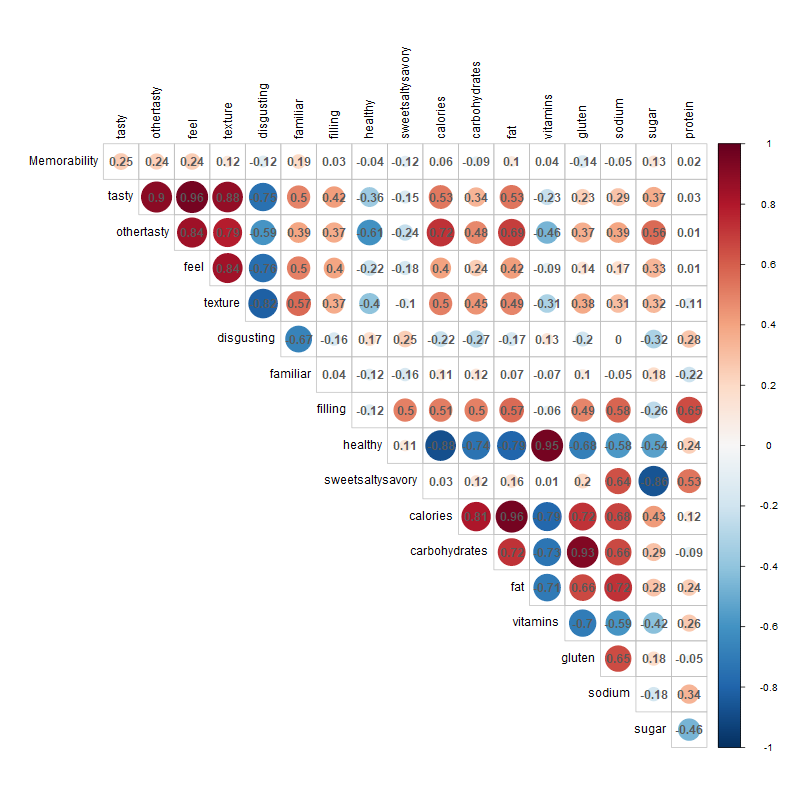

```r
knitr::include_graphics("C:/Users/Christine/Box Sync/data/mem_dm_all_results/visualization/corr.png")
```

### Correlation with tastiness

Duplicate code from manuscript (Lloyd et al., 2020)

Performed factor analysis of the ratings from the manuscript, and ran multiple regression to see if memorability scores can be predicted by the 3 factors (Tastiness, Healthiness, Sweet and savory).

```r
# factor analysis
nFactors::nCng(as.data.frame(rmat.nochoice), model="factors")
```

```
## [1] 3
```

```r
fit <- factanal(rmat.nochoice, 3, scores="regression")

scores3 <- fit$scores
ind1 <- which.max(fit$loadings[rownames(fit$loadings) == "unhealthy",])
ind2 <- which.max(fit$loadings[rownames(fit$loadings) == "tasty",])
ind3 <- which.max(fit$loadings[rownames(fit$loadings) == "sweetsaltysavory",])
colnames(scores3) <- c("Food.UnHealth", "Food.Taste", "Food.SweetProtein")
outdf <- data.frame(subjectId=food$subjectId, stimulus=food$stimulus, scores3)

# score of factor for each food item
ave.factor = outdf %>% group_by(stimulus) %>%
  summarise_all(mean)

# add mem score to the factor data frame
labels = sapply(mem$stimulus, function(x) which(ave.factor$stimulus == x))
ave.factor.mem = data.frame(Memorability = mem$Memorability, mem.stimulus = mem$X, ave.factor)
```

Result showed that only **tastiness** factor can predict the variances in memorability scores (p = 0.004)

```r
# perform linear regression
fit1 = lm(Memorability ~ Food.Taste + Food.UnHealth + Food.SweetProtein, data = ave.factor.mem)
summary(fit1)
```

```
##
## Call:
## lm(formula = Memorability ~ Food.Taste + Food.UnHealth + Food.SweetProtein,
##     data = ave.factor.mem)
##
## Residuals:
##      Min       1Q   Median       3Q      Max
## -0.44521 -0.08271 -0.00198  0.08395  0.36137
##
## Coefficients:
##                    Estimate Std. Error t value Pr(>|t|)
## (Intercept)        0.471386   0.010631  44.342  < 2e-16 ***
## Food.Taste         0.083737   0.028708   2.917  0.00415 **
## Food.UnHealth     -0.008655   0.014046  -0.616  0.53882
## Food.SweetProtein -0.008280   0.014440  -0.573  0.56732
## ---
## Signif. codes:  0 '***' 0.001 '**' 0.01 '*' 0.05 '.' 0.1 ' ' 1
##
## Residual standard error: 0.1249 on 134 degrees of freedom
## Multiple R-squared:  0.0693, Adjusted R-squared:  0.04847
## F-statistic: 3.326 on 3 and 134 DF,  p-value: 0.02169
```

Scatter plot for memorability scores and averaged tastiness score for the factor analysis on each food item (p = 0.004).

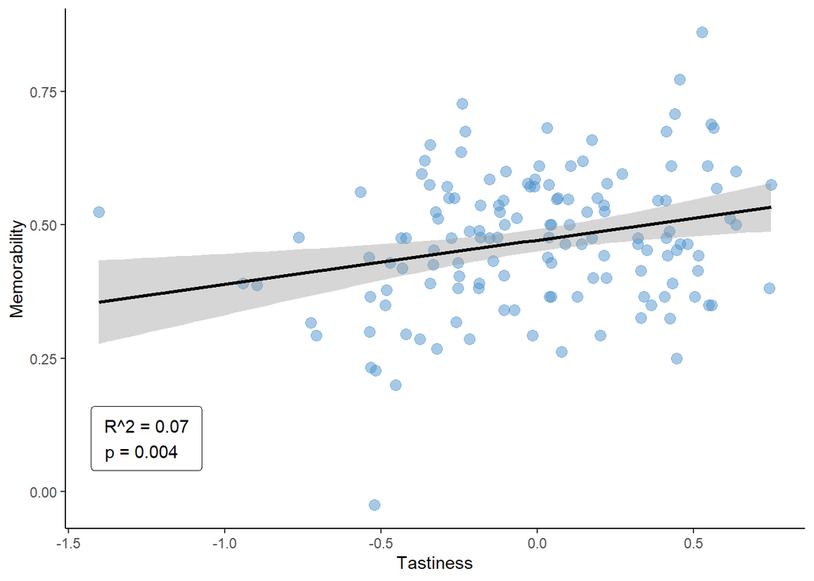

```r
# plot mem~food.taste
ave.factor.mem %>% ggplot(aes(x = Food.Taste, y = Memorability))+
  geom_point(size = 3, alpha = 0.5, color = "steelblue3", fill = "steelblue")+
  geom_smooth(method='lm', color = 'black')+
  xlab('Tastiness')+
  theme_classic()+
  geom_label(
    label="R^2 = 0.07\np = 0.004  ",
    x=-1.25,
    y=0.1,
    label.padding = unit(0.55, "lines"), # Rectangle size around label
    label.size = 0.35,
    color = "black",
    fill="white"
  )
```

```r
ggsave('C:/Users/Christine/Box Sync/data/mem_dm_all_results/visualization/scatter.png', width = 5, height = 4, units = 'in')
```

## Experiment 2: Image Choice Task (N = 44)

Load the cleaned choice trials and rating trials from **cleaned_choice.csv** and **cleaned_rating.csv** in the [image] folder. The raw data is saved as **full_data_image_dm.csv**

The original data excluded participants who:

1. tended to choose left or right items disproportionately
2. average RT was less than 300 ms in more than half of the trials
3. had negative parameter estimates or non-significant effect of ΔValues on choices (beta)

```r
## Setup for exp2
#loading data files
choice = read.csv('C:/Users/Christine/Box Sync/data/mem_dm_all_results/cleaned data/image/cleaned_choice.csv')
rating = read.csv('C:/Users/Christine/Box Sync/data/mem_dm_all_results/cleaned data/image/cleaned_rating.csv')
```

z-scored image values for each participant, and calculated delta z-scored values for each choice trial

```r
## z-score values for each subject
#calculate z scores within each ID
rating.merge = rating[c('ID', 'z', 'image')]
rating.merge.l = rating.merge %>% rename(stim_left = image)
rating.merge.r = rating.merge %>% rename(stim_right = image)

#merge columns based on ID and stimuli names
choice.z = merge(rating.merge.l, choice, by = c('ID', 'stim_left')) %>%
  rename(z.value.l = z)
choice.z = merge(rating.merge.r, choice.z, by = c('ID', 'stim_right')) %>%
  rename(z.value.r = z)
choice.z = choice.z %>% mutate(z.delta.value = z.value.r - z.value.l)
```

### Image choice ~ value * image memorability

Run multiple regression model of Image choice ~ value * image memorability with random effects.

No effect found for memorability.

```r
# generate the model
# m1 = glmer(choseright~1+delta.mem*z.delta.value+(1+delta.mem*z.delta.value|ID),
#            data = choice.z, family = "binomial",
#            glmerControl(optimizer = "bobyqa", optCtrl = list(maxfun = 100000)))
# save(m1, file="C:/Users/Christine/Box Sync/data/mem_dm_all_results/models/m1_imageChoiceMem.RData")

load("C:/Users/Christine/Box Sync/data/mem_dm_all_results/models/m1_imageChoiceMem.RData")
summary(m1)
```

```
## Generalized linear mixed model fit by maximum likelihood (Laplace
##   Approximation) [glmerMod]
##  Family: binomial  ( logit )
## Formula: choseright ~ 1 + delta.mem * z.delta.value + (1 + delta.mem *
##     z.delta.value | ID)
##    Data: choice.z
## Control: glmerControl(optimizer = "bobyqa", optCtrl = list(maxfun = 1e+05))
##
##      AIC      BIC   logLik deviance df.resid
##   6376.3   6469.7  -3174.1   6348.3     5845
##
## Scaled residuals:
##     Min      1Q  Median      3Q     Max
## -5.9867 -0.9041 -0.1303  0.9119  4.6790
##
## Random effects:
##  Groups Name                    Variance Std.Dev. Corr
##  ID     (Intercept)             0.047860 0.21877
##         delta.mem               0.006336 0.07960   0.20
##         z.delta.value           0.248659 0.49866  -0.16 -1.00
##         delta.mem:z.delta.value 0.002476 0.04976  -1.00 -0.25  0.20
## Number of obs: 5859, groups:  ID, 44
##
## Fixed effects:
##                         Estimate Std. Error z value Pr(>|z|)
## (Intercept)             -0.01854    0.04534  -0.409    0.683
## delta.mem               -0.01891    0.17234  -0.110    0.913
## z.delta.value            1.20103    0.08538  14.067   <2e-16 ***
## delta.mem:z.delta.value -0.01643    0.21834  -0.075    0.940
## ---
## Signif. codes:  0 '***' 0.001 '**' 0.01 '*' 0.05 '.' 0.1 ' ' 1
##
## Correlation of Fixed Effects:
##             (Intr) dlt.mm z.dlt.
## delta.mem    0.024
## z.delta.val -0.102 -0.080
## dlt.mm:z.d. -0.052 -0.005  0.012
## optimizer (bobyqa) convergence code: 0 (OK)
## boundary (singular) fit: see ?isSingular
```

```r
#plot_model(m1)
#plt.value = plot_model(m1, type = "pred", terms="z.delta.value [all]")
#plt.mem = plot_model(m1, type = "pred", terms="z.delta.mem [all]")

#confint(m1)
```

### RT ~ absolute delta mememorability * absolute delta value

No effect found for memorability on RT

Only z-scored delta value able to predict RT, where higher value results in lower RT.

```r
## model for RT
choice.z = choice.z %>% mutate(abs.delta.v.z = abs(z.delta.value))
# m2 = lmer(log(rt)~1+abs(delta.mem)*abs.delta.v.z+(1+abs(delta.mem)*abs.delta.v.z|ID),
#            data = choice.z)
#
# save(m2, file="C:/Users/Christine/Box Sync/data/mem_dm_all_results/models/m2_imageRTMem.RData")

load("C:/Users/Christine/Box Sync/data/mem_dm_all_results/models/m2_imageRTMem.RData")
summary(m2)
```

```
## Linear mixed model fit by REML ['lmerMod']
## Formula: log(rt) ~ 1 + abs(delta.mem) * abs.delta.v.z + (1 + abs(delta.mem) *
##     abs.delta.v.z | ID)
##    Data: choice.z
##
## REML criterion at convergence: 2088.4
##
## Scaled residuals:
##     Min      1Q  Median      3Q     Max
## -4.5770 -0.6474 -0.0486  0.5772  5.3706
##
## Random effects:
##  Groups   Name                         Variance Std.Dev. Corr
##  ID       (Intercept)                  0.051553 0.22705
##           abs(delta.mem)               0.005327 0.07298   0.57
##           abs.delta.v.z                0.002314 0.04810  -0.61 -0.59
##           abs(delta.mem):abs.delta.v.z 0.001925 0.04388   0.10 -0.41  0.71
##  Residual                              0.079831 0.28254
## Number of obs: 5859, groups:  ID, 44
##
## Fixed effects:
##                               Estimate Std. Error t value
## (Intercept)                   7.053319   0.035226 200.231
## abs(delta.mem)               -0.051909   0.047317  -1.097
## abs.delta.v.z                -0.042067   0.009928  -4.237
## abs(delta.mem):abs.delta.v.z  0.006681   0.038392   0.174
##
## Correlation of Fixed Effects:
##             (Intr) abs(.) abs...
## abs(dlt.mm) -0.051
## abs.dlt.v.z -0.545  0.262
## abs(d.):...  0.143 -0.680 -0.439
## optimizer (nloptwrap) convergence code: 0 (OK)
## Model failed to converge with max|grad| = 0.00281815 (tol = 0.002, component 1)
```

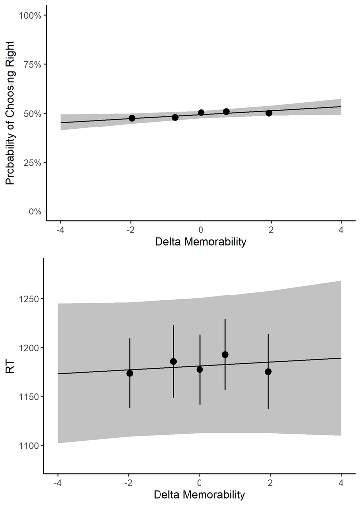

```r
#plot_model(m2)
#confint(m3,method="Wald")

knitr::include_graphics("C:/Users/Christine/Box Sync/data/mem_dm_all_results/visualization/mem.png")
```

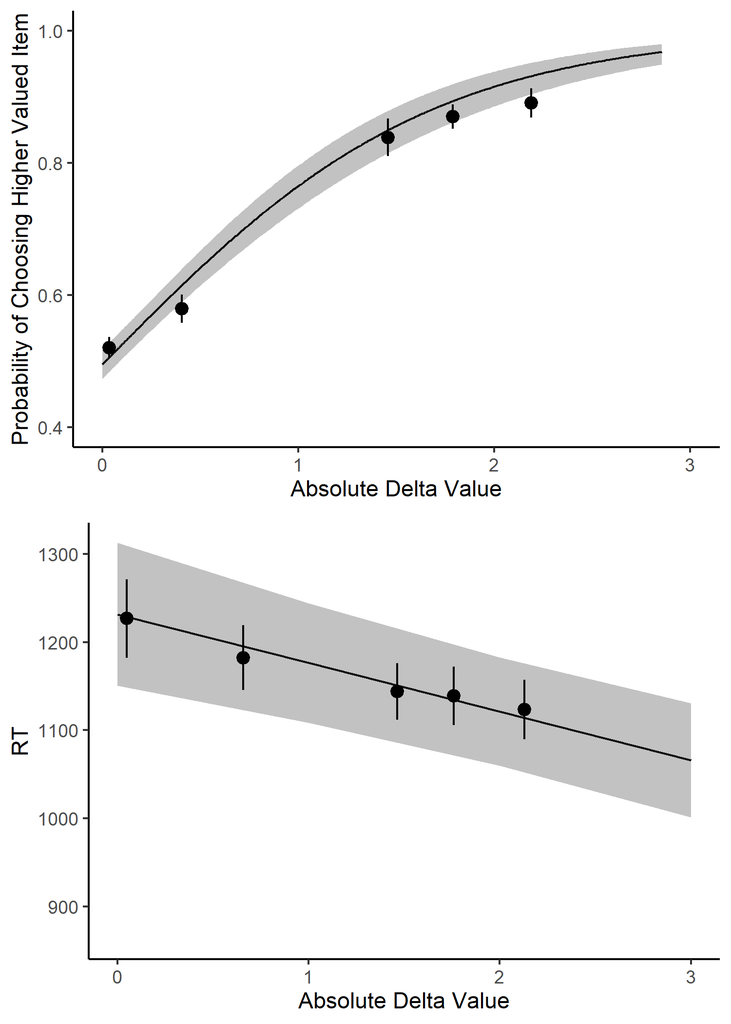

```r
knitr::include_graphics("C:/Users/Christine/Box Sync/data/mem_dm_all_results/visualization/value.png")
```

## Experiment 3: Word Memorability (N = 199)

Followed same exclusion criteria as the image version.

### Distribution of word memorability

The lowest one is **skittles**, and the highest one is **omelet**

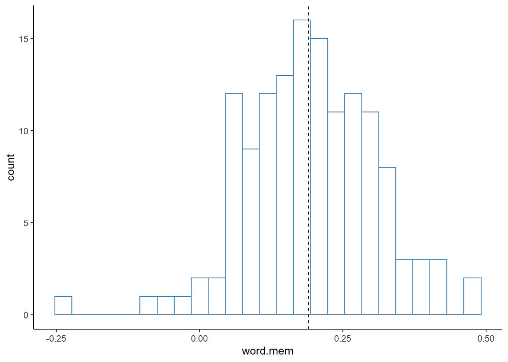

```r
## ggplot histogram
ggplot(mem['word.mem'], aes(x=word.mem)) +
  geom_histogram(color="steelblue", fill="white", bins = 25) +
  geom_vline(xintercept = 0.19,linetype = "dashed") +
  theme_classic()
```

```r
ggsave('C:/Users/Christine/Box Sync/data/mem_dm_all_results/visualization/hist_word.png', width = 7, height = 4, units = 'in')
```

## Experiment 4: Word Choice Task (N = 44)

Load the cleaned choice trials and rating trials from **cleaned_choice.csv** and **cleaned_rating.csv**

The cleaned data applied the same exclusion criteria, and the original full data can be found at **full_word_choice.csv**

```r
## load word choice data
rating = read.csv('C:/Users/Christine/Box Sync/data/mem_dm_all_results/cleaned data/word/cleaned_rating.csv')
choice = read.csv('C:/Users/Christine/Box Sync/data/mem_dm_all_results/cleaned data/word/cleaned_choice.csv')

#calculate mean values for each stimuli
values = rating %>% dplyr::group_by(word) %>% dplyr::summarise(value = mean(as.numeric(response)))
#combine mean values with mem measures
values_mem = merge(values, mem, by.x = 'word', by.y = "food.item.e", sort = TRUE)
```

### Model for choice behavior

Fitted mixted effects model for delta memorability and delta value, and found no effect of delta word_mem, but strong effect of delta value for predicting the behavior (same as image memorability)

```r
#mixted effects model for delta mem and delta value
# m3 = glmer(choseright~1+delta.mem*delta.value+(1+delta.mem*delta.value|ID), data = choice, family = "binomial")
# save(m3, file="C:/Users/Christine/Box Sync/data/mem_dm_all_results/models/m3_wordChoiceMem.RData")

load("C:/Users/Christine/Box Sync/data/mem_dm_all_results/models/m3_wordChoiceMem.RData")
summary(m3)
```

```
## Generalized linear mixed model fit by maximum likelihood (Laplace
##   Approximation) [glmerMod]
##  Family: binomial  ( logit )
## Formula:
## choseright ~ 1 + delta.mem * delta.value + (1 + delta.mem * delta.value |
##     ID)
##    Data: choice
##
##      AIC      BIC   logLik deviance df.resid
##   6093.8   6187.6  -3032.9   6065.8     5986
##
## Scaled residuals:
##     Min      1Q  Median      3Q     Max
## -8.4491 -0.8958 -0.0981  0.9520  8.0687
##
## Random effects:
##  Groups Name                  Variance  Std.Dev. Corr
##  ID     (Intercept)           0.0221745 0.14891
##         delta.mem             0.0809045 0.28444  -0.37
##         delta.value           0.0006018 0.02453  -0.29  0.84
##         delta.mem:delta.value 0.0003149 0.01774  -0.79  0.44  0.04
## Number of obs: 6000, groups:  ID, 44
##
## Fixed effects:
##                        Estimate Std. Error z value Pr(>|z|)
## (Intercept)           -0.110232   0.038853  -2.837  0.00455 **
## delta.mem             -0.091941   0.200363  -0.459  0.64633
## delta.value            0.054239   0.004193  12.935  < 2e-16 ***
## delta.mem:delta.value  0.002190   0.011589   0.189  0.85010
## ---
## Signif. codes:  0 '***' 0.001 '**' 0.01 '*' 0.05 '.' 0.1 ' ' 1
##
## Correlation of Fixed Effects:
##             (Intr) dlt.mm dlt.vl
## delta.mem   -0.050
## delta.value -0.159  0.158
## dlt.mm:dlt. -0.114  0.018  0.017
## optimizer (Nelder_Mead) convergence code: 0 (OK)
## Model failed to converge with max|grad| = 0.00620777 (tol = 0.002, component 1)
```

```r
#plot_model(m3, type = "pred")
```

### Model for RT

RT ~ delta.mem*absolute.delta.value.z with mixed effects Only z scored delta value able to predict RT, where higher value results in lower RT.

```r
## model for RT
# choice = choice %>% mutate(abs.delta.v.z = abs(z.delta.value))
# m4 = lmer(log(rt)~1+abs(delta.mem)*abs.delta.v.z+(1+abs(delta.mem)*abs.delta.v.z|ID),
#            data = choice)
# save(m4, file="C:/Users/Christine/Box Sync/data/mem_dm_all_results/models/m4_wordRTMem.RData")

load("C:/Users/Christine/Box Sync/data/mem_dm_all_results/models/m4_wordRTMem.RData")
summary(m4)
```

```
## Linear mixed model fit by REML ['lmerMod']
## Formula: log(rt) ~ 1 + abs(delta.mem) * abs.delta.v.z + (1 + abs(delta.mem) *
##     abs.delta.v.z | ID)
##    Data: choice
##
## REML criterion at convergence: 1201.6
##
## Scaled residuals:
##     Min      1Q  Median      3Q     Max
## -6.0326 -0.6273 -0.0635  0.6023  4.0802
##
## Random effects:
##  Groups   Name                         Variance Std.Dev. Corr
##  ID       (Intercept)                  0.030458 0.17452
##           abs(delta.mem)               0.014838 0.12181  -0.29
##           abs.delta.v.z                0.002743 0.05238  -0.48  0.91
##           abs(delta.mem):abs.delta.v.z 0.014557 0.12065   0.11 -0.24 -0.57
##  Residual                              0.068599 0.26191
## Number of obs: 6000, groups:  ID, 44
##
## Fixed effects:
##                               Estimate Std. Error t value
## (Intercept)                   7.154086   0.027455 260.573
## abs(delta.mem)               -0.033265   0.051926  -0.641
## abs.delta.v.z                -0.054993   0.011153  -4.931
## abs(delta.mem):abs.delta.v.z -0.003189   0.052378  -0.061
##
## Correlation of Fixed Effects:
##             (Intr) abs(.) abs...
## abs(dlt.mm) -0.308
## abs.dlt.v.z -0.473  0.601
## abs(d.):...  0.187 -0.662 -0.659
## optimizer (nloptwrap) convergence code: 0 (OK)
## boundary (singular) fit: see ?isSingular
```

```r
#confint(m4,method="Wald")
```

### Correlations between value and memorability for image/words

There’s significant correlation between averaged word value and image memorability (p = 0.03)

```r
# correlation between rated value in word choices and image memorability
cor.test(x = values_mem$value, y = values_mem$Memorability)
```

```
##
##  Pearson's product-moment correlation
##
## data:  values_mem$value and values_mem$Memorability
## t = 2.1204, df = 136, p-value = 0.03579
## alternative hypothesis: true correlation is not equal to 0
## 95 percent confidence interval:
##  0.01214496 0.33594912
## sample estimates:
##       cor
## 0.1788868
```

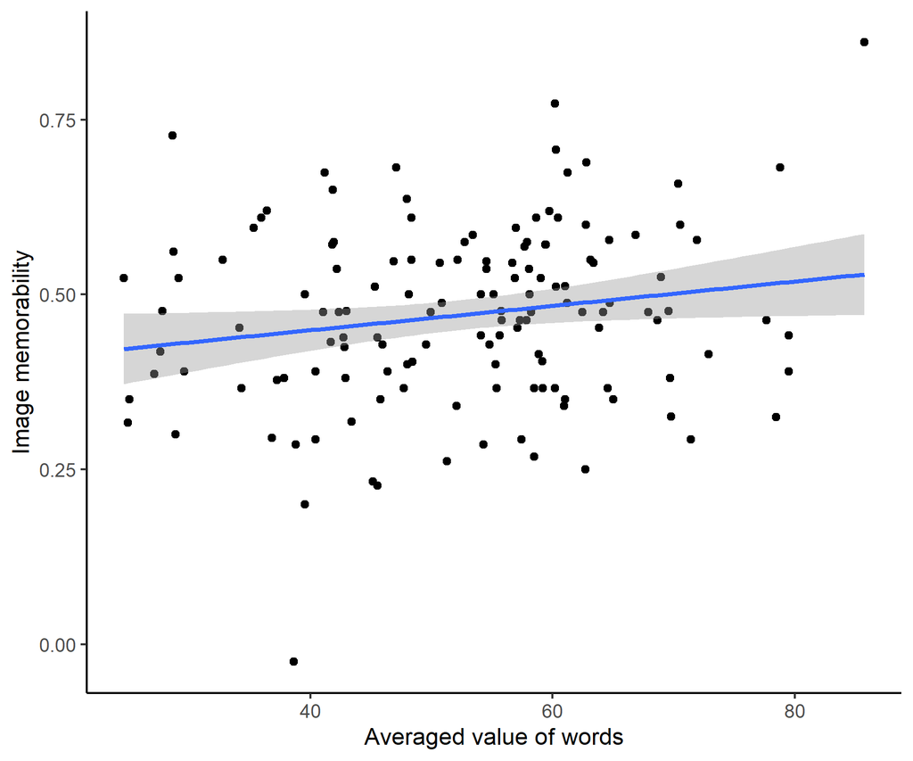

```r
# plot the correlation
p.scatter.value.mem = values_mem %>% ggplot(aes(x = value, y = Memorability)) +
  geom_point() +
  geom_smooth(method = 'lm') +
  xlab("Averaged value of words")+
  ylab("Image memorability") +
  theme_classic()

ggsave('C:/Users/Christine/Box Sync/data/mem_dm_all_results/visualization/p.scatter.value.mem.png', height = 5, width = 6)
knitr::include_graphics("C:/Users/Christine/Box Sync/data/mem_dm_all_results/visualization/p.scatter.value.mem.png")
```

```r
# correlation between rated value in word choices and word memorability
cor.test(x = values_mem$value, y = values_mem$word.mem)
```

```
##
##  Pearson's product-moment correlation
##
## data:  values_mem$value and values_mem$word.mem
## t = 0.64624, df = 136, p-value = 0.5192
## alternative hypothesis: true correlation is not equal to 0
## 95 percent confidence interval:
##  -0.1128183  0.2203967
## sample estimates:
##        cor
## 0.05532962
```

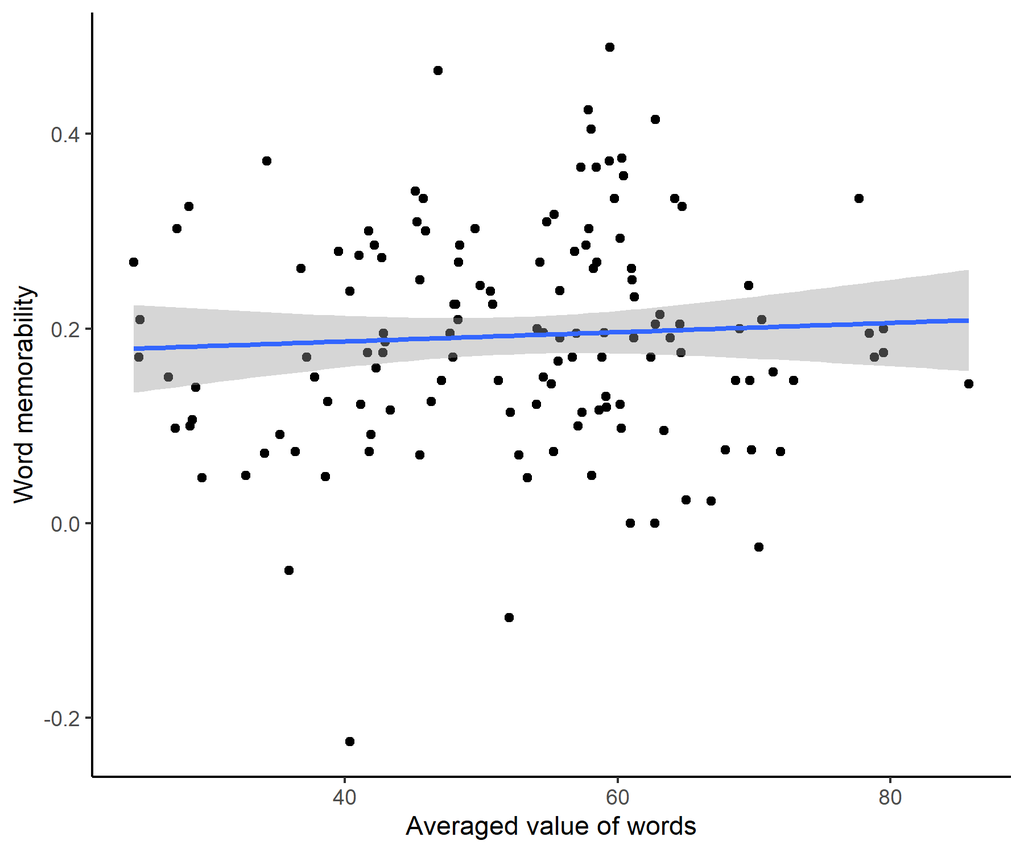

```r
# plot the correlation
p.scatter.value.word = values_mem %>% ggplot(aes(x = value, y = word.mem)) +
  geom_point() +
  geom_smooth(method = 'lm') +
  xlab("Averaged value of words")+
  ylab("Word memorability") +
  theme_classic()

ggsave('C:/Users/Christine/Box Sync/data/mem_dm_all_results/visualization/p.scatter.value.word.png', height = 5, width = 6)
knitr::include_graphics("C:/Users/Christine/Box Sync/data/mem_dm_all_results/visualization/p.scatter.value.word.png")
```

### Image mem and word choices

There’s a significant positive relation between word choices and image memorability (p = 0.01), even after the value of words are controlled.

`How to understand this result?`

```r
## Try to calculate image mem and choice behavior
choice.im = merge(choice, mem[c('food.item.e', 'Memorability')], by.x = "stim_left", by.y = "food.item.e") %>% rename(image.m.l = Memorability)
choice.im = merge(choice.im, mem[c('food.item.e', 'Memorability')], by.x = "stim_right", by.y = "food.item.e") %>% rename(image.m.r = Memorability) %>% mutate(delta.im.mem = image.m.r - image.m.l)

#mixted effects model for delta mem and delta value
# m3 = glmer(choseright~1+delta.im.mem*delta.value+(1+delta.im.mem*delta.value|ID), data = choice.rep, family = "binomial")
# summary(m3)
#
# save(m3, file="C:/Users/Christine/Box Sync/data/mem_dm_all_results/models/m3_imagemem_wordvalue.RData")

load("C:/Users/Christine/Box Sync/data/mem_dm_all_results/models/m3_imagemem_wordvalue.RData")
summary(m3)
```

```
## Generalized linear mixed model fit by maximum likelihood (Laplace
##   Approximation) [glmerMod]
##  Family: binomial  ( logit )
## Formula: choseright ~ 1 + delta.im.mem * delta.value + (1 + delta.im.mem *
##     delta.value | ID)
##    Data: choice.rep
##
##      AIC      BIC   logLik deviance df.resid
##   5901.7   5995.1  -2936.9   5873.7     5812
##
## Scaled residuals:
##     Min      1Q  Median      3Q     Max
## -8.1295 -0.8674 -0.0957  0.9209  8.6169
##
## Random effects:
##  Groups Name                     Variance  Std.Dev. Corr
##  ID     (Intercept)              0.0234851 0.15325
##         delta.im.mem             0.6406019 0.80038  -0.24
##         delta.value              0.0005565 0.02359  -0.32 -0.10
##         delta.im.mem:delta.value 0.0002049 0.01431   0.79  0.21 -0.74
## Number of obs: 5826, groups:  ID, 44
##
## Fixed effects:
##                           Estimate Std. Error z value Pr(>|z|)
## (Intercept)              -0.106296   0.039739  -2.675  0.00748 **
## delta.im.mem              0.540011   0.215229   2.509  0.01211 *
## delta.value               0.053967   0.004057  13.303  < 2e-16 ***
## delta.im.mem:delta.value -0.012827   0.010322  -1.243  0.21398
## ---
## Signif. codes:  0 '***' 0.001 '**' 0.01 '*' 0.05 '.' 0.1 ' ' 1
##
## Correlation of Fixed Effects:
##             (Intr) dlt.m. dlt.vl
## delta.im.mm -0.090
## delta.value -0.178 -0.052
## dlt.m.mm:d.  0.091  0.012 -0.170
## optimizer (Nelder_Mead) convergence code: 0 (OK)
## boundary (singular) fit: see ?isSingular
```

```
## Data were 'prettified'. Consider using `terms="delta.im.mem [all]"` to get smooth plots.
```

```
## Data were 'prettified'. Consider using `terms="delta.value [all]"` to get smooth plots.
```

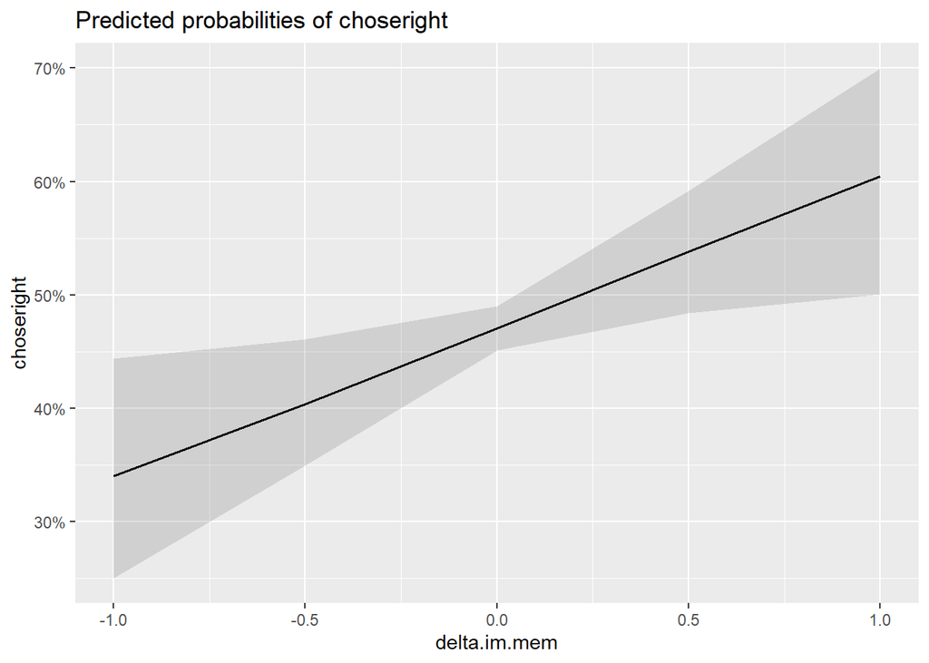

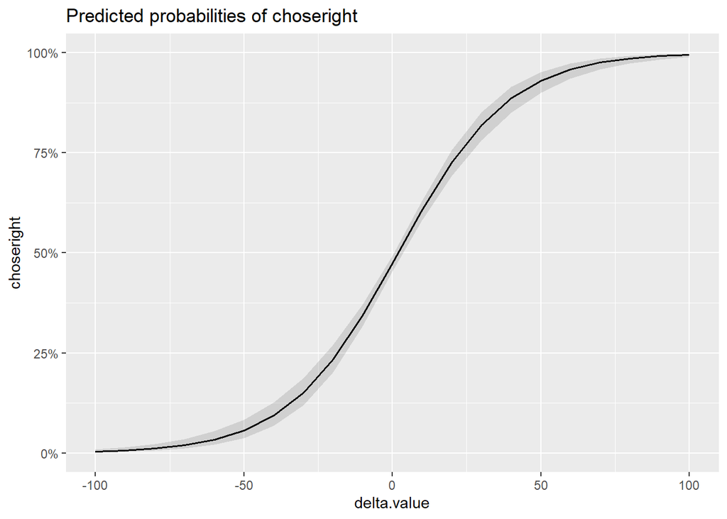

```r
plot_model(m3, type = "pred")
```

## Experiment 5: Representativeness of Image

Item-level Representativeness data can be accessed at **rep-mean.csv**

Original data is saved in file **rep-task.csv** (N = 40)

```r
# load rep data
rep = read.csv('C:/Users/Christine/Box Sync/data//mem_dm_all_results/cleaned data/rep-mean.csv') %>% select(-X, -n)
mem = merge(rep, mem, by.x = "word", by.y = "food.item.e")
```

### Averaged data for each image

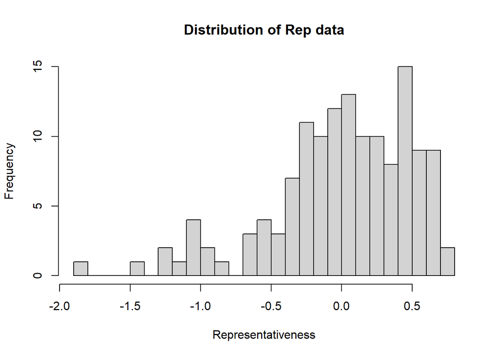

```r
  hist(mem$rep.z, breaks = 20, main = paste("Distribution of Rep data"), xlab = "Representativeness")
```

### Correlations

No correlation between word or image memorability and the rep data

```r
# possible correlation between representativeness of images and memorability
# found not null correlations
cor.test(mem$rep.z, mem$word.mem)
```

```
##
##  Pearson's product-moment correlation
##
## data:  mem$rep.z and mem$word.mem
## t = -0.14335, df = 136, p-value = 0.8862
## alternative hypothesis: true correlation is not equal to 0
## 95 percent confidence interval:
##  -0.1790280  0.1551326
## sample estimates:
##         cor
## -0.01229084
```

```r
# no correlation with image memorability
cor.test(mem$rep.z, mem$Memorability)
```

```
##
##  Pearson's product-moment correlation
##
## data:  mem$rep.z and mem$Memorability
## t = 0.9629, df = 136, p-value = 0.3373
## alternative hypothesis: true correlation is not equal to 0
## 95 percent confidence interval:
##  -0.0859997  0.2460097
## sample estimates:
##        cor
## 0.08228769
```

Found positive correlation between rep data and tastiness of food images

```r
# positive correlation with tastiness of food images
cor.test(mem$tasty, mem$rep.z)
```

```
##
##  Pearson's product-moment correlation
##
## data:  mem$tasty and mem$rep.z
## t = 2.6596, df = 136, p-value = 0.008763
## alternative hypothesis: true correlation is not equal to 0
## 95 percent confidence interval:
##  0.0573762 0.3755020
## sample estimates:
##       cor
## 0.2223492
```

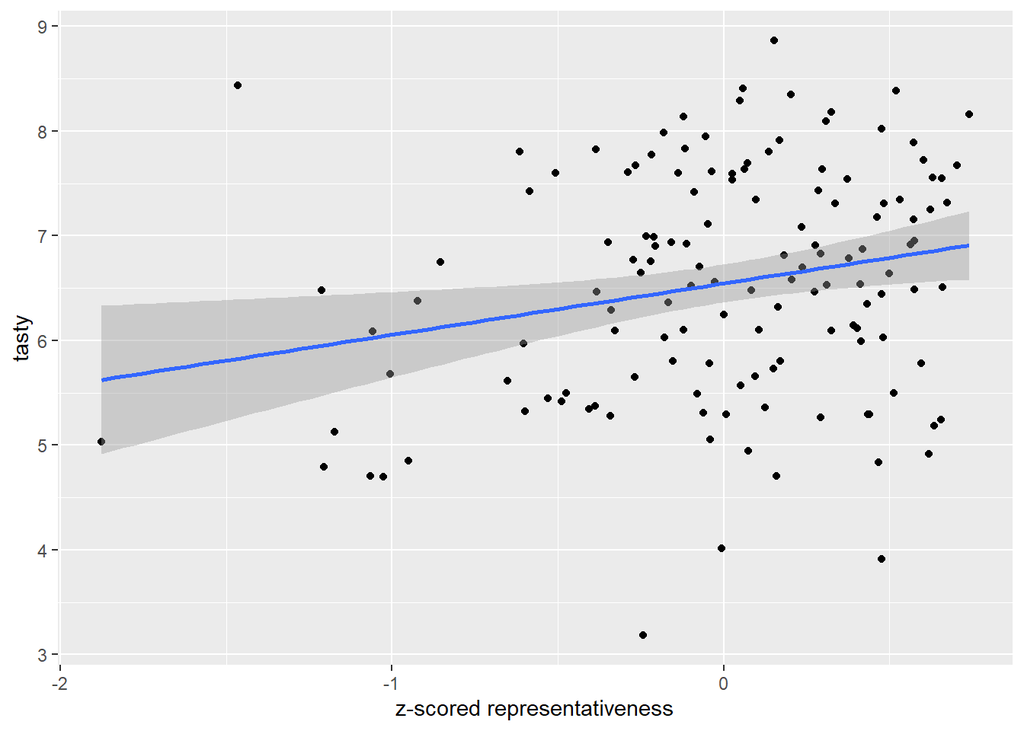

```r
mem %>% ggplot(aes(x = rep.z, y = tasty)) +
  geom_point()+
  geom_smooth(method = 'lm')+
  xlab("z-scored representativeness")
```

### Try to fit in the model

Add the difference of representativeness into the model of word value and image memorability

p of choosing right ~ delta image memorability * delta word value * delta rep (with random effects)

```r
## Merge image rep data to choice task
choice.rep = merge(choice.im, mem[c('word', 'rep.z')], by.x = "stim_left", by.y = "word") %>% rename(rep.l = rep.z)
choice.rep = merge(choice.rep, mem[c('word', 'rep.z')], by.x = "stim_right", by.y = "word") %>% rename(rep.r = rep.z) %>% mutate(delta.rep = rep.r - rep.l)

# run regression model for image mem, word value, and representativeness of image
# m5 = glmer(choseright~1+delta.im.mem*delta.value*delta.rep+(1+delta.im.mem*delta.value*delta.rep|ID),
#            data = choice.rep, family = "binomial",
#            glmerControl(optimizer = "bobyqa", optCtrl = list(maxfun = 100000)))

load("C:/Users/Christine/Box Sync/data/mem_dm_all_results/models/m5_rep.RData")
summary(m5)
```

```
## Generalized linear mixed model fit by maximum likelihood (Laplace
##   Approximation) [glmerMod]
##  Family: binomial  ( logit )
## Formula: choseright ~ 1 + delta.im.mem * delta.value * delta.rep + (1 +
##     delta.im.mem * delta.value * delta.rep | ID)
##    Data: choice.rep
## Control: glmerControl(optimizer = "bobyqa", optCtrl = list(maxfun = 1e+05))
##
##      AIC      BIC   logLik deviance df.resid
##   5940.4   6233.9  -2926.2   5852.4     5782
##
## Scaled residuals:
##     Min      1Q  Median      3Q     Max
## -8.4778 -0.8504 -0.0962  0.8940  7.6481
##
## Random effects:
##  Groups Name                               Variance  Std.Dev. Corr
##  ID     (Intercept)                        2.454e-02 0.15666
##         delta.im.mem                       5.897e-01 0.76790  -0.23
##         delta.value                        5.682e-04 0.02384  -0.26 -0.14
##         delta.rep                          6.092e-03 0.07805  -0.37  0.82  0.02
##         delta.im.mem:delta.value           2.289e-04 0.01513   0.70  0.05 -0.79
##         delta.im.mem:delta.rep             2.913e-01 0.53970   0.46 -0.41 -0.67
##         delta.value:delta.rep              2.218e-05 0.00471   0.18 -0.22  0.82
##         delta.im.mem:delta.value:delta.rep 1.828e-04 0.01352  -0.42 -0.44  0.59
##
##
##
##
##
##  -0.31
##  -0.74  0.81
##   0.08 -0.57 -0.64
##  -0.56 -0.45  0.04  0.13
## Number of obs: 5826, groups:  ID, 44
##
## Fixed effects:
##                                     Estimate Std. Error z value Pr(>|z|)
## (Intercept)                        -0.104191   0.040285  -2.586  0.00970 **
## delta.im.mem                        0.478462   0.214643   2.229  0.02581 *
## delta.value                         0.054637   0.004115  13.279  < 2e-16 ***
## delta.rep                           0.152646   0.047873   3.189  0.00143 **
## delta.im.mem:delta.value           -0.015946   0.010660  -1.496  0.13467
## delta.im.mem:delta.rep             -0.082348   0.258000  -0.319  0.74959
## delta.value:delta.rep               0.005545   0.002728   2.033  0.04207 *
## delta.im.mem:delta.value:delta.rep -0.001267   0.013960  -0.091  0.92769
## ---
## Signif. codes:  0 '***' 0.001 '**' 0.01 '*' 0.05 '.' 0.1 ' ' 1
##
## Correlation of Fixed Effects:
##                (Intr) dlt.m. dlt.vl dlt.rp dlt.m.mm:dlt.v dlt.m.mm:dlt.r dlt.:.
## delta.im.mm    -0.093
## delta.value    -0.145 -0.074
## delta.rep      -0.048  0.038  0.023
## dlt.m.mm:dlt.v  0.074 -0.003 -0.198 -0.016
## dlt.m.mm:dlt.r  0.020 -0.030 -0.184 -0.052  0.093
## dlt.vl:dlt.     0.052 -0.031  0.268 -0.025 -0.103         -0.059
## dlt.m.m:.:.    -0.037 -0.007  0.060 -0.019  0.189          0.005         -0.031
## optimizer (bobyqa) convergence code: 0 (OK)
## boundary (singular) fit: see ?isSingular
```

```
## Data were 'prettified'. Consider using `terms="delta.im.mem [all]"` to get smooth plots.
```

```
## Data were 'prettified'. Consider using `terms="delta.value [all]"` to get smooth plots.
```

```
## Data were 'prettified'. Consider using `terms="delta.rep [all]"` to get smooth plots.
```

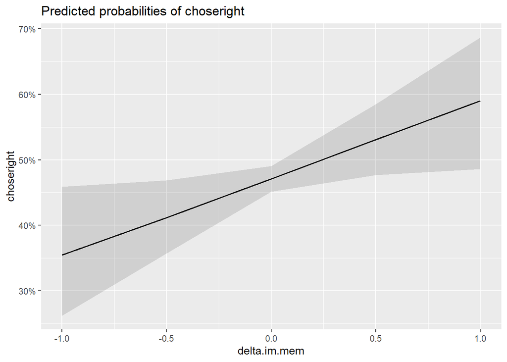

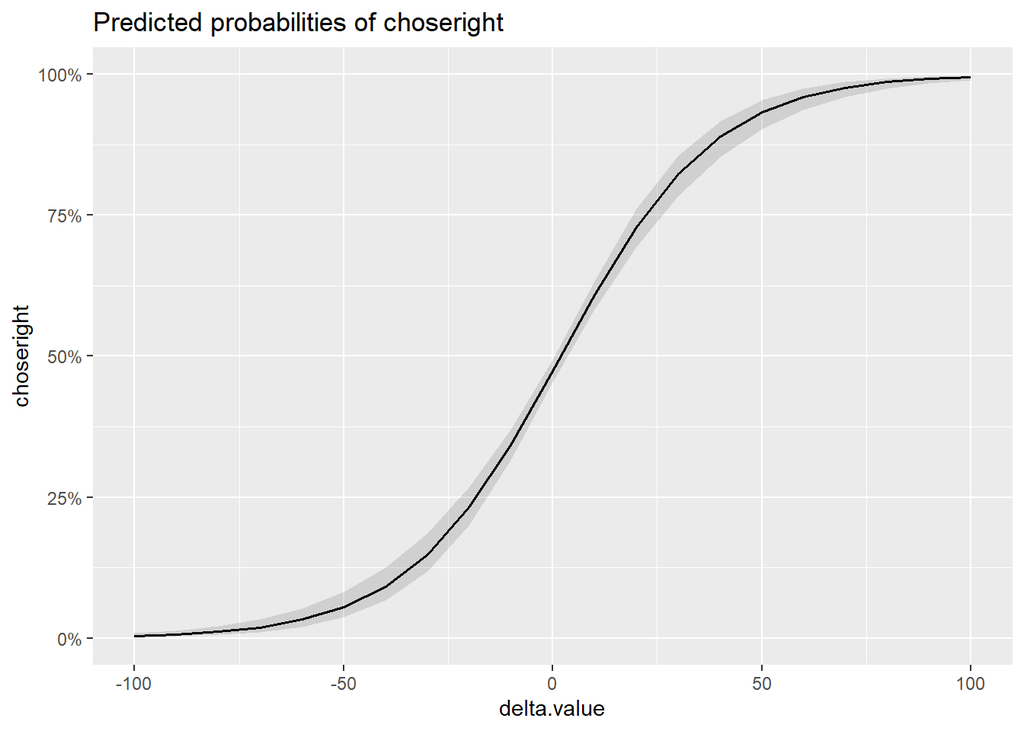

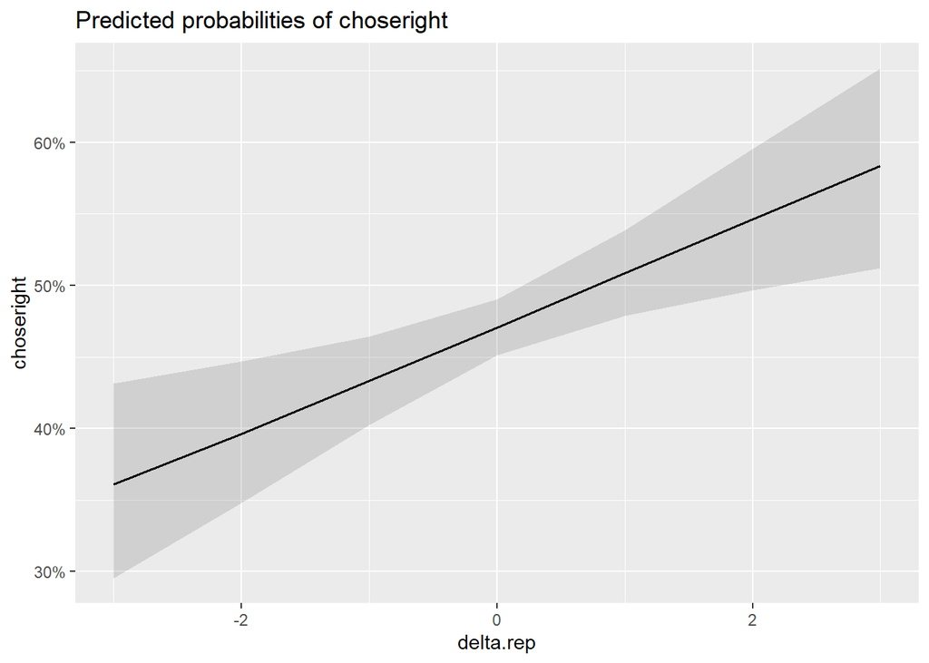

```r
#save(m5, file="C:/Users/Christine/Box Sync/data/mem_dm_all_results/models/m5_rep.RData")
plot_model(m5, type = "pred")
```

### Comparing models

Model with representative data did not perform significantly better than the simpler version

```r
anova(m3, m5)
```

```
## Data: choice.rep
## Models:
## m3: choseright ~ 1 + delta.im.mem * delta.value + (1 + delta.im.mem *
## m3:     delta.value | ID)
## m5: choseright ~ 1 + delta.im.mem * delta.value * delta.rep + (1 +
## m5:     delta.im.mem * delta.value * delta.rep | ID)
##    npar    AIC    BIC  logLik deviance  Chisq Df Pr(>Chisq)
## m3   14 5901.7 5995.1 -2936.9   5873.7
## m5   44 5940.4 6233.9 -2926.2   5852.4 21.323 30     0.8775
```

### Correlation Matrix

Generate the full correlation matrix with image/word memorability scores, representativeness data, and food ratings.

```r
# merge mem data and food rating data
mem.corr = mem %>% select(rep.z, X, HR.x, FAR.x, HR.y, FAR.y, ResMem, word.mem)
ave.mat.r.full = merge(ave.mat.r, mem.corr, by.x = "mem.stimulus", by.y = "X") %>% rename(HR.image = HR.x, FAR.image = FAR.x, HR.word = HR.y, FAR.word = FAR.y)

new.ord = c("Memorability", "HR.image", "FAR.image","word.mem", "HR.word", "FAR.word", "ResMem", "rep.z", "tasty", "othertasty", "feel", "texture", "disgusting", "familiar", "filling", "healthy", "sweetsaltysavory", "calories", "carbohydrates", "fat", "vitamins", "gluten", "sodium", "sugar", "protein")


# correlation matrix with memorability score
#ave.mat.r = rdat[,new.ord] %>%

M.mem.full = ave.mat.r.full[,new.ord] %>% cor()
diag(M.mem.full) = 0
png(height=800, width=800, file="C:/Users/Christine/Box Sync/data/mem_dm_all_results/visualization/corr_full.png", type = "cairo")
corrplot(M.mem.full, method="circle", diag = F, #order="hclust",
         #is.corr=F, cl.lim=c(-0.85,0.85),
         col=rev(colorRampPalette(brewer.pal(n=11, name="RdBu"))(256)),
         tl.col='black',
         #tl.cex=1.2,
         addCoef.col="grey35",
         type = "upper")

dev.off()
```

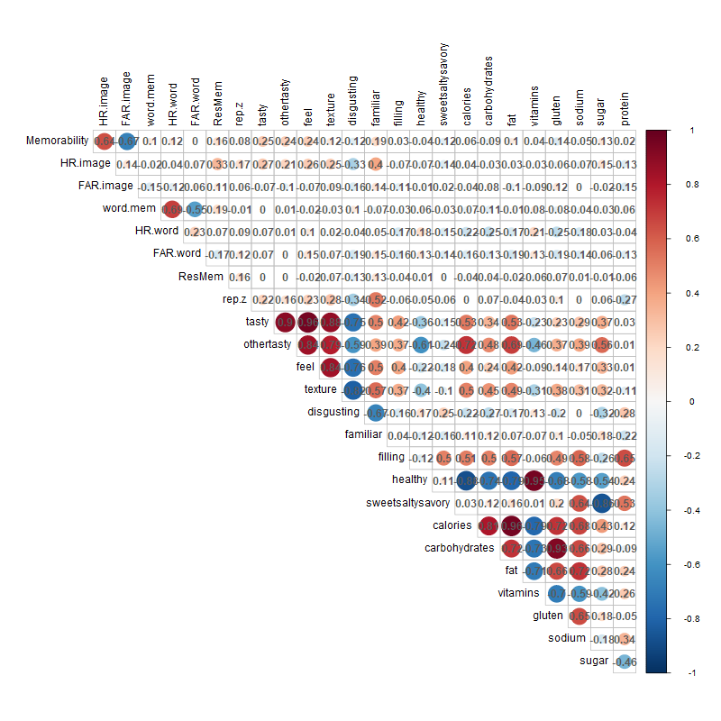

```r
knitr::include_graphics("C:/Users/Christine/Box Sync/data/mem_dm_all_results/visualization/corr_full.png")
```